# Exploring Cell-Type Shifts Between Healthy and COPD Lung Tissue Using CELLxGENE Discover

Author

Andre Gala-Garza

Published

March 13, 2026

**Disclaimer:** Generative AI was used to assist with drafting report information and templating and writing code in this assignment; however, this writing was checked manually and edited by hand to ensure accuracy.

**Source:** OpenAI. (2026). *ChatGPT (GPT-5.4 Thinking)* [Large language model]. https://chatgpt.com/.

# Introduction

Chronic obstructive pulmonary disease (COPD) is a lung condition caused by damage to the lungs, which leads to swelling and irritation (a.k.a. inflammation), limited airflow to the lungs, and trouble breathing (Mayo Clinic). It is most frequently caused by long-term exposure to irritating smoke or fumes, especially cigarette smoke. The two most common types of COPD are chronic bronchitis, when the lining of the tubes that bring air into the lungs called bronchi are inflamed, and emphysema, which damages the small air sacs of the lungs called alveoli and prevent them from passing enough oxygen to the bloodstream (Mayo Clinic). To understand how COPD develops, an important type of investigation is to find the types of cells that are causing the condition.

There are many distinct cell populations contained in the lung, including epithetial (outer surface) cells. The alveolar type 1 (AT1) cells and alveolar type 2 (AT2) cells are particularly significant for maintaining gas exchange in the alveolar environment (Schiller et al). A previous study published in the *American Journal of Respiratory Cell and Molecular Biology* has explored the contents of lung cells with an isolated analysis technique known as single-cell RNA sequencing, which revealed a significant presence of AT2 cells in the lungs of those with COPD (Watanave et al). The dataset used in the study has been shared publicly, allowing further investigation into the provided single-cell RNA-seq data. This project aims to elaborate on this analysis from a visualization perspective by exploring the following question: **How do cell-type compositions and selected marker gene expression patterns differ between healthy and COPD lung tissue?**

# Data Preparation

The data used in this project comes from the study “Anomalous Epithelial Variations and Ectopic Inflammatory Response in Chronic Obstructive Pulmonary Disease” and is made publicly available by the study authors through CZ CELLxGENE Discover, a data platform developed by the Chan Zuckerberg Initiative. The dataset was downloaded in H5AD format, which is a file type commonly used for single-cell genomics data. This format stores the data as an AnnData object, allowing both cell-level metadata and gene expression measurements to be accessed in a structured way for analysis in R.

To prepare the data, the H5AD file was read into R using the anndata package with support from reticulate. The cell-level metadata were extracted from the “obs” component of the AnnData object and converted into a data frame. From this metadata, a smaller set of variables relevant to the research question was retained, including sample identifiers, donor identifiers, disease status, cell type, sex, tissue, sample collection site, tissue type, and sample source.

In addition, expression values were extracted for a small set of selected genes of interest: SFTPC, ABCA3, AGER, and SFTPB. These genes were chosen because they are biologically relevant markers of alveolar epithelial cell identity and function, particularly for distinguishing alveolar type 1 (AT1) and alveolar type 2 (AT2) cell states in the lung. The filtered gene expression data were then combined with the selected metadata variables to create a cleaned analysis dataset for exploratory analysis and visualization.

```r
ad <- read_h5ad("data.h5ad")

cols_keep <- c(
  "sample_id",
  "donor_id",
  "disease",
  "cell_type",
  "sex",
  "tissue",
  "sample_collection_site",
  "tissue_type",
  "sample_source"
)

metadata_df <- as.data.frame(ad$obs[, cols_keep])
gene_names <- as.character(ad$var_names)

genes_keep <- c(
  SFTPC = "ENSG00000168484",
  ABCA3 = "ENSG00000167972",
  AGER  = "ENSG00000204305",
  SFTPB = "ENSG00000168878"
)

genes_present <- genes_keep[genes_keep %in% gene_names]

expr_df <- as.data.frame(ad[, unname(genes_present)]$to_df())
colnames(expr_df) <- names(genes_present)

full_df <- cbind(metadata_df, expr_df)
```

## Dataset characteristics

The following code computes the overall size of the analytic dataset, including the numbers of cells, variables, donors, samples, disease groups, and cell types.

```r
n_rows <- nrow(full_df)
n_cols <- ncol(full_df)
n_donors <- n_distinct(full_df$donor_id)
n_samples <- n_distinct(full_df$sample_id)
n_diseases <- n_distinct(full_df$disease)
n_cell_types <- n_distinct(full_df$cell_type)

data_summary <- data.frame(
  Metric = c(
    "Number of cells",
    "Number of variables",
    "Number of donors",
    "Number of samples",
    "Number of disease groups",
    "Number of cell types"
  ),
  Value = c(n_rows, n_cols, n_donors, n_samples, n_diseases, n_cell_types)
)

kable_style(data_summary, caption = "Dataset characteristics")
```

Dataset characteristics

| Metric | Value |
| --- | --- |
| Number of cells | 57918 |
| Number of variables | 13 |
| Number of donors | 16 |
| Number of samples | 16 |
| Number of disease groups | 2 |
| Number of cell types | 21 |

This table shows that the analytic dataset is fairly large, with 57,918 cells spanning 16 donors, 16 samples, and 21 cell types across two disease groups.

## Variables included

The cleaned dataset includes donor- and sample-level identifiers, disease status, cell type, sex, tissue descriptors, sample source information, and the four selected gene expression variables.

The following code lists the variables retained in the cleaned dataset and their corresponding data types.

```r
variable_summary <- data.frame(
  Variable = colnames(full_df),
  Type = sapply(full_df, class)
)

kable_style(variable_summary, caption = "Variables included in the cleaned dataset")
```

Variables included in the cleaned dataset

|  | Variable | Type |
| --- | --- | --- |
| sample_id | sample_id | factor |
| donor_id | donor_id | factor |
| disease | disease | factor |
| cell_type | cell_type | factor |
| sex | sex | factor |
| tissue | tissue | factor |
| sample_collection_site | sample_collection_site | factor |
| tissue_type | tissue_type | factor |
| sample_source | sample_source | factor |
| SFTPC | SFTPC | numeric |
| ABCA3 | ABCA3 | numeric |
| AGER | AGER | numeric |
| SFTPB | SFTPB | numeric |

This table confirms that the cleaned dataset combines nine metadata variables with four numeric gene expression variables for the selected marker panel.

## Missing data

Missingness is evaluated at the variable level so that any incomplete metadata or gene expression fields can be identified before interpreting results.

The following code summarizes the amount of missing data for each variable so that completeness can be assessed systematically.

```r
missing_summary <- data.frame(
  Variable = colnames(full_df),
  Missing_Count = sapply(full_df, function(x) sum(is.na(x))),
  Missing_Proportion = sapply(full_df, function(x) mean(is.na(x)))
)

kable_style(missing_summary, caption = "Missingness summary")
```

Missingness summary

|  | Variable | Missing_Count | Missing_Proportion |
| --- | --- | --- | --- |
| sample_id | sample_id | 0 | 0 |
| donor_id | donor_id | 0 | 0 |
| disease | disease | 0 | 0 |
| cell_type | cell_type | 0 | 0 |
| sex | sex | 0 | 0 |
| tissue | tissue | 0 | 0 |
| sample_collection_site | sample_collection_site | 0 | 0 |
| tissue_type | tissue_type | 0 | 0 |
| sample_source | sample_source | 0 | 0 |
| SFTPC | SFTPC | 0 | 0 |
| ABCA3 | ABCA3 | 0 | 0 |
| AGER | AGER | 0 | 0 |
| SFTPB | SFTPB | 0 | 0 |

This table indicates that there is no missing data in the metadata or selected gene expression variables used for this analysis.

## Distribution of key categorical variables

The following code tabulates the number of cells observed in each disease group.

```r
disease_counts <- full_df %>%
  count(disease, sort = TRUE) %>%
  mutate(disease = fct_reorder(disease, n))

kable_style(disease_counts, caption = "Cell counts by disease status")
```

Cell counts by disease status

| disease | n |
| --- | --- |
| normal | 35799 |
| chronic obstructive pulmonary disease | 22119 |

This table shows that the dataset contains more cells from normal tissue than from COPD tissue.

The following figure visualizes the distribution of cells across disease groups.

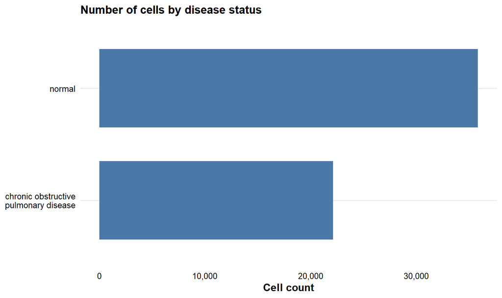

Distribution of cells across disease groups. Bars are ordered from smallest to largest group size to make differences easier to compare.

```r
ggplot(disease_counts, aes(x = disease, y = n)) +
  geom_col(width = 0.7, fill = "#4C78A8") +
  coord_flip() +
  scale_y_continuous(labels = comma) +
  scale_x_discrete(labels = wrap_axis) +
  labs(
    title = "Number of cells by disease status",
    x = NULL,
    y = "Cell count"
  )
```

This bar chart reinforces that normal samples contribute more cells overall than COPD samples, which is important context for interpreting later group comparisons.

The following code tabulates the most common cell types in the analytic dataset.

```r
cell_type_counts <- full_df %>%
  count(cell_type, sort = TRUE)

kable_style(head(cell_type_counts, 15), caption = "Top 15 cell types by count")
```

Top 15 cell types by count

| cell_type | n |
| --- | --- |
| CD4-positive, alpha-beta T cell | 11365 |
| natural killer cell | 8423 |
| capillary endothelial cell | 6393 |
| macrophage | 4289 |
| CD8-positive, alpha-beta T cell | 4136 |
| monocyte | 3425 |
| fibroblast | 3022 |
| conventional dendritic cell | 2808 |
| mast cell | 2413 |
| pulmonary alveolar type 2 cell | 2144 |
| vein endothelial cell | 2015 |
| lung multiciliated epithelial cell | 1950 |
| smooth muscle cell | 1279 |
| endothelial cell | 912 |
| B cell | 712 |

This table shows that T cells, natural killer cells, endothelial cells, and macrophages are among the most common cell populations in the dataset, while pulmonary alveolar type 2 cells are present but less abundant overall.

The following figure displays the 15 most common cell types by frequency.

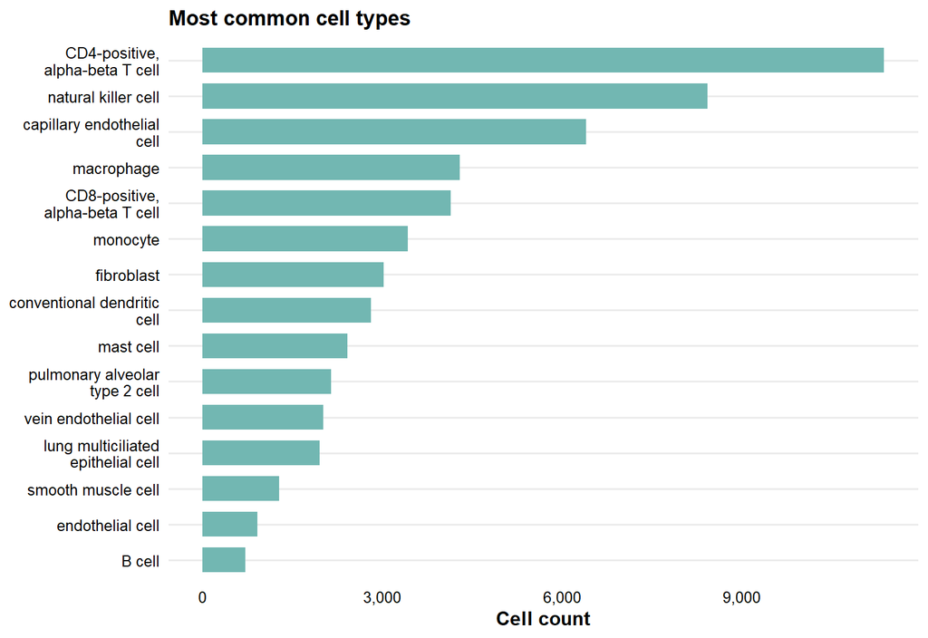

Top 15 cell types by frequency in the analytic dataset.

```r
cell_type_counts %>%
  slice_max(order_by = n, n = 15) %>%
  mutate(cell_type = fct_reorder(cell_type, n)) %>%
  ggplot(aes(x = cell_type, y = n)) +
  geom_col(width = 0.7, fill = "#72B7B2") +
  coord_flip() +
  scale_y_continuous(labels = comma) +
  scale_x_discrete(labels = wrap_axis) +
  labs(
    title = "Most common cell types",
    x = NULL,
    y = "Cell count"
  )
```

This plot shows that a small set of immune and endothelial populations makes up much of the dataset, with CD4-positive T cells being the most abundant cell type.

The following code summarizes the number of cells contributed by each recorded sex category.

```r
sex_counts <- full_df %>%
  count(sex, sort = TRUE)

kable_style(sex_counts, caption = "Cell counts by sex")
```

Cell counts by sex

| sex | n |
| --- | --- |
| male | 37631 |
| female | 20287 |

This table shows that more cells in the dataset come from male donors than from female donors.

The following figure shows the distribution of cells by recorded sex.

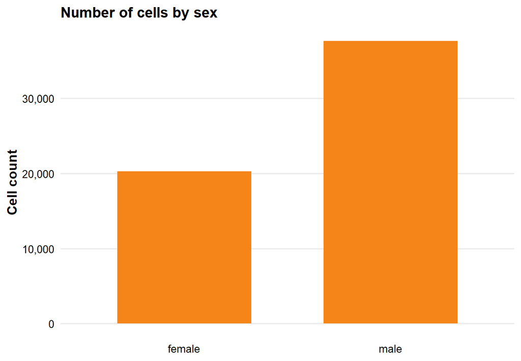

Cell counts by recorded sex.

```r
ggplot(sex_counts, aes(x = fct_reorder(sex, n), y = n)) +
  geom_col(width = 0.65, fill = "#F58518") +
  scale_y_continuous(labels = comma) +
  labs(
    title = "Number of cells by sex",
    x = NULL,
    y = "Cell count"
  )
```

This bar chart mirrors the table by showing a noticeably larger number of cells from male donors than from female donors.

## Distribution of key gene expression variables

The following code calculates summary statistics for the selected gene expression variables across all cells.

```r
gene_summary <- full_df %>%
  summarise(
    ABCA3_mean = mean(ABCA3, na.rm = TRUE),
    ABCA3_median = median(ABCA3, na.rm = TRUE),
    SFTPB_mean = mean(SFTPB, na.rm = TRUE),
    SFTPB_median = median(SFTPB, na.rm = TRUE),
    SFTPC_mean = mean(SFTPC, na.rm = TRUE),
    SFTPC_median = median(SFTPC, na.rm = TRUE),
    AGER_mean = mean(AGER, na.rm = TRUE),
    AGER_median = median(AGER, na.rm = TRUE)
  )

kable_style(gene_summary, caption = "Summary statistics for selected genes")
```

Summary statistics for selected genes

| ABCA3_mean | ABCA3_median | SFTPB_mean | SFTPB_median | SFTPC_mean | SFTPC_median | AGER_mean | AGER_median |
| --- | --- | --- | --- | --- | --- | --- | --- |
| 0.102 | 0 | 0.328 | 0 | 0.895 | 0.564 | 0.047 | 0 |

This table shows that SFTPC has the highest overall expression among the selected genes, while ABCA3 and especially AGER are much sparser across all cells.

The following code tabulates the proportion of nonzero expression values for the selected genes.

```r
selected_gene_nonzero <- full_df %>%
  summarise(across(all_of(names(genes_present)), ~ mean(.x != 0, na.rm = TRUE))) %>%
  tidyr::pivot_longer(
    cols = everything(),
    names_to = "Gene",
    values_to = "Proportion_Nonzero"
  )

kable_style(selected_gene_nonzero, caption = "Proportion of nonzero expression values for selected genes")
```

Proportion of nonzero expression values for selected genes

| Gene | Proportion_Nonzero |
| --- | --- |
| SFTPC | 0.625 |
| ABCA3 | 0.094 |
| AGER | 0.044 |
| SFTPB | 0.217 |

This table shows that SFTPC is nonzero in the largest share of cells, followed by SFTPB, while ABCA3 and AGER are detected in much smaller proportions of cells.

The following figure shows the distribution of nonzero proportions across all genes with zero-proportion genes excluded.

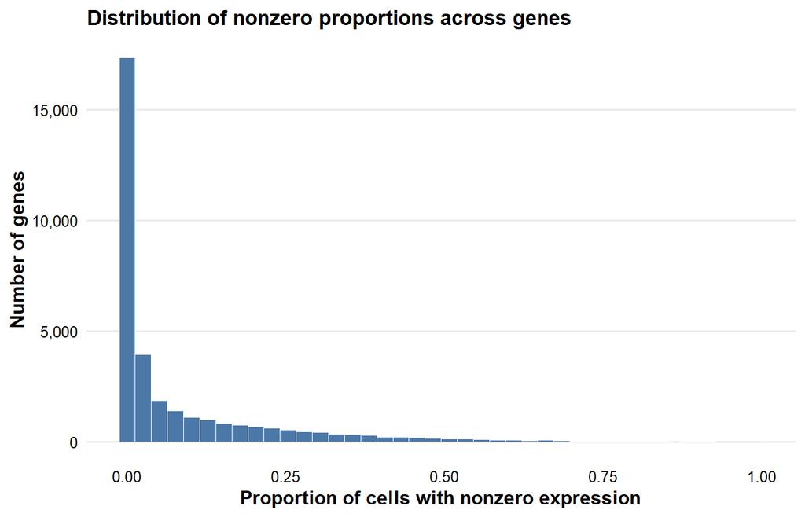

Distribution of gene-level nonzero expression proportions across all genes, excluding genes with a proportion of 0.

```r
nonzero_prop <- Matrix::colMeans(ad$X != 0)
gene_nonzero_df <- data.frame(
  gene = gene_names,
  prop_nonzero = nonzero_prop
)

ggplot(gene_nonzero_df %>% filter(prop_nonzero > 0), aes(x = prop_nonzero)) +
  geom_histogram(bins = 40, fill = "#4C78A8", color = "white", linewidth = 0.2) +
  scale_y_continuous(labels = comma) +
  labs(
    title = "Distribution of nonzero proportions across genes",
    x = "Proportion of cells with nonzero expression",
    y = "Number of genes"
  )
```

This histogram shows that most genes are nonzero in only a small fraction of cells even after excluding genes with zero nonzero proportion, which is consistent with the sparse nature of single-cell RNA-seq data.

# Preliminary Results

## Cell type composition across disease groups

The following code summarizes cell type counts and within-disease proportions to evaluate compositional differences across disease groups.

```r
disease_celltype_counts <- full_df %>%
  count(disease, cell_type) %>%
  group_by(disease) %>%
  mutate(prop = n / sum(n)) %>%
  ungroup()

kable_style(
  head(disease_celltype_counts, 20),
  caption = "Cell type counts and proportions by disease"
)
```

Cell type counts and proportions by disease

| disease | cell_type | n | prop |
| --- | --- | --- | --- |
| chronic obstructive pulmonary disease | fibroblast | 741 | 0.034 |
| chronic obstructive pulmonary disease | mast cell | 1193 | 0.054 |
| chronic obstructive pulmonary disease | endothelial cell | 325 | 0.015 |
| chronic obstructive pulmonary disease | club cell | 395 | 0.018 |
| chronic obstructive pulmonary disease | smooth muscle cell | 443 | 0.020 |
| chronic obstructive pulmonary disease | macrophage | 2002 | 0.091 |
| chronic obstructive pulmonary disease | B cell | 345 | 0.016 |
| chronic obstructive pulmonary disease | monocyte | 1636 | 0.074 |
| chronic obstructive pulmonary disease | natural killer cell | 2744 | 0.124 |
| chronic obstructive pulmonary disease | CD4-positive, alpha-beta T cell | 4187 | 0.189 |
| chronic obstructive pulmonary disease | CD8-positive, alpha-beta T cell | 1537 | 0.069 |
| chronic obstructive pulmonary disease | leukocyte | 185 | 0.008 |
| chronic obstructive pulmonary disease | neutrophil | 164 | 0.007 |
| chronic obstructive pulmonary disease | plasma cell | 179 | 0.008 |
| chronic obstructive pulmonary disease | conventional dendritic cell | 1132 | 0.051 |
| chronic obstructive pulmonary disease | pulmonary alveolar type 1 cell | 219 | 0.010 |
| chronic obstructive pulmonary disease | pulmonary alveolar type 2 cell | 848 | 0.038 |
| chronic obstructive pulmonary disease | endothelial cell of lymphatic vessel | 127 | 0.006 |
| chronic obstructive pulmonary disease | capillary endothelial cell | 1992 | 0.090 |
| chronic obstructive pulmonary disease | vein endothelial cell | 829 | 0.037 |

This table suggests that COPD samples contain substantial contributions from immune populations such as CD4-positive T cells, natural killer cells, macrophages, and monocytes, alongside smaller AT1 and AT2 compartments.

The following code identifies the most abundant cell types overall and prepares a disease-specific composition dataset for visualization.

```r
top_cell_types <- disease_celltype_counts %>%
  group_by(cell_type) %>%
  summarise(total = sum(n), .groups = "drop") %>%
  slice_max(order_by = total, n = 10) %>%
  pull(cell_type)

plot_celltype_comp <- full_df %>%
  filter(cell_type %in% top_cell_types) %>%
  count(disease, cell_type) %>%
  group_by(disease) %>%
  mutate(prop = n / sum(n)) %>%
  ungroup() %>%
  mutate(cell_type = fct_reorder(cell_type, n, .fun = sum))
```

This code creates the grouped composition dataset used to compare how the dominant cell types are distributed within each disease category.

The following figure compares the relative composition of the most abundant cell types across disease groups.

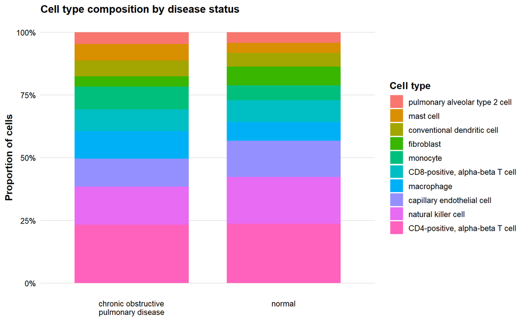

Relative cell type composition within each disease group, restricted to the 10 most abundant cell types overall.

```r
ggplot(plot_celltype_comp, aes(x = disease, y = prop, fill = cell_type)) +
  geom_col(width = 0.75) +
  scale_y_continuous(labels = percent_format(accuracy = 1)) +
  scale_x_discrete(labels = wrap_axis) +
  labs(
    title = "Cell type composition by disease status",
    x = NULL,
    y = "Proportion of cells",
    fill = "Cell type"
  ) +
  guides(fill = guide_legend(ncol = 1))
```

This stacked bar chart suggests that the overall composition of the most abundant cell types is broadly similar across disease groups, but with modest shifts in the relative contributions of immune and epithelial populations.

## Gene expression by disease

The following code computes disease-specific summary statistics for each selected gene to address the primary research question.

```r
gene_disease_summary <- full_df %>%
  group_by(disease) %>%
  summarise(
    n = n(),
    ABCA3_mean = mean(ABCA3, na.rm = TRUE),
    ABCA3_median = median(ABCA3, na.rm = TRUE),
    SFTPB_mean = mean(SFTPB, na.rm = TRUE),
    SFTPB_median = median(SFTPB, na.rm = TRUE),
    SFTPC_mean = mean(SFTPC, na.rm = TRUE),
    SFTPC_median = median(SFTPC, na.rm = TRUE),
    AGER_mean = mean(AGER, na.rm = TRUE),
    AGER_median = median(AGER, na.rm = TRUE)
  )

kable_style(gene_disease_summary, caption = "Summary statistics for selected genes by disease status")
```

Summary statistics for selected genes by disease status

| disease | n | ABCA3_mean | ABCA3_median | SFTPB_mean | SFTPB_median | SFTPC_mean | SFTPC_median | AGER_mean | AGER_median |
| --- | --- | --- | --- | --- | --- | --- | --- | --- | --- |
| chronic obstructive pulmonary disease | 22119 | 0.088 | 0 | 0.336 | 0 | 0.733 | 0.197 | 0.040 | 0 |
| normal | 35799 | 0.110 | 0 | 0.323 | 0 | 0.995 | 0.705 | 0.051 | 0 |

This table shows that mean expression is lower in COPD for ABCA3 and SFTPC, slightly higher in COPD for SFTPB, and that the medians remain zero for several genes because of persistent sparsity.

The following figure compares ABCA3 expression distributions across disease groups.

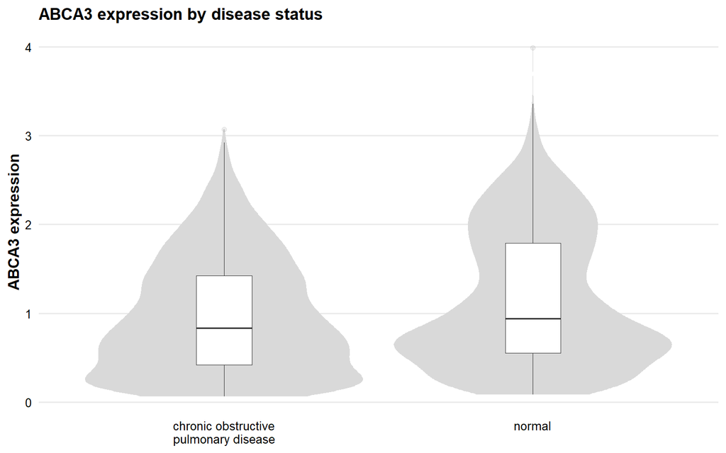

Distribution of nonzero ABCA3 expression by disease group. Violin plots show the nonzero distribution, while boxplots summarize the median and interquartile range.

```r
ggplot(full_df %>% filter(ABCA3 > 0), aes(x = disease, y = ABCA3)) +
  geom_violin(fill = "gray85", color = NA, scale = "width") +
  geom_boxplot(width = 0.18, outlier.alpha = 0.08, linewidth = 0.3) +
  scale_x_discrete(labels = wrap_axis) +
  labs(
    title = "ABCA3 expression by disease status",
    x = NULL,
    y = "ABCA3 expression"
  )
```

This plot suggests that among cells with detectable expression, ABCA3 values tend to be somewhat lower in COPD than in normal tissue.

The following figure compares SFTPB expression distributions across disease groups.

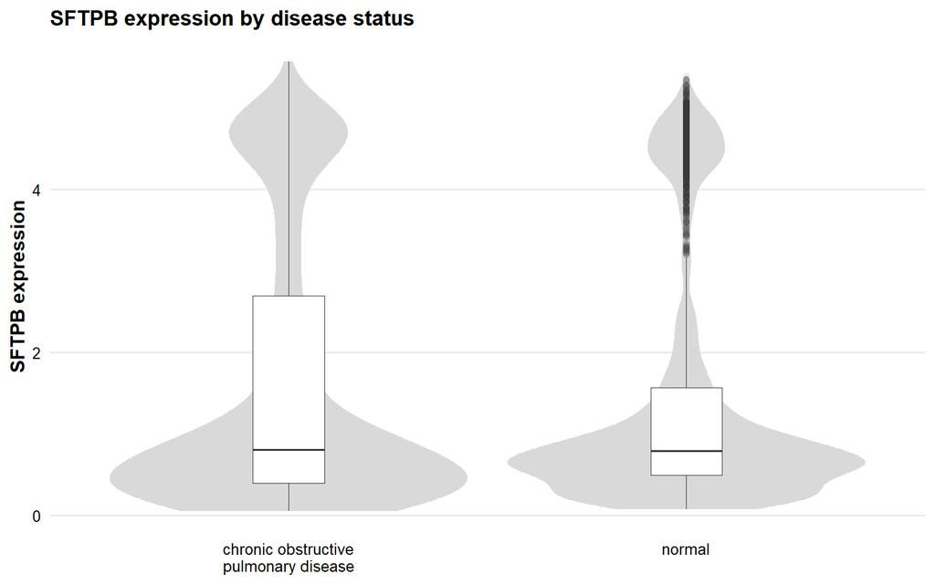

Distribution of nonzero SFTPB expression by disease group.

```r
ggplot(full_df %>% filter(SFTPB > 0), aes(x = disease, y = SFTPB)) +
  geom_violin(fill = "gray85", color = NA, scale = "width") +
  geom_boxplot(width = 0.18, outlier.alpha = 0.08, linewidth = 0.3) +
  scale_x_discrete(labels = wrap_axis) +
  labs(
    title = "SFTPB expression by disease status",
    x = NULL,
    y = "SFTPB expression"
  )
```

This plot suggests that the nonzero distribution of SFTPB is fairly similar across disease groups, with at most a modest elevation in COPD.

The following figure compares SFTPC expression distributions across disease groups.

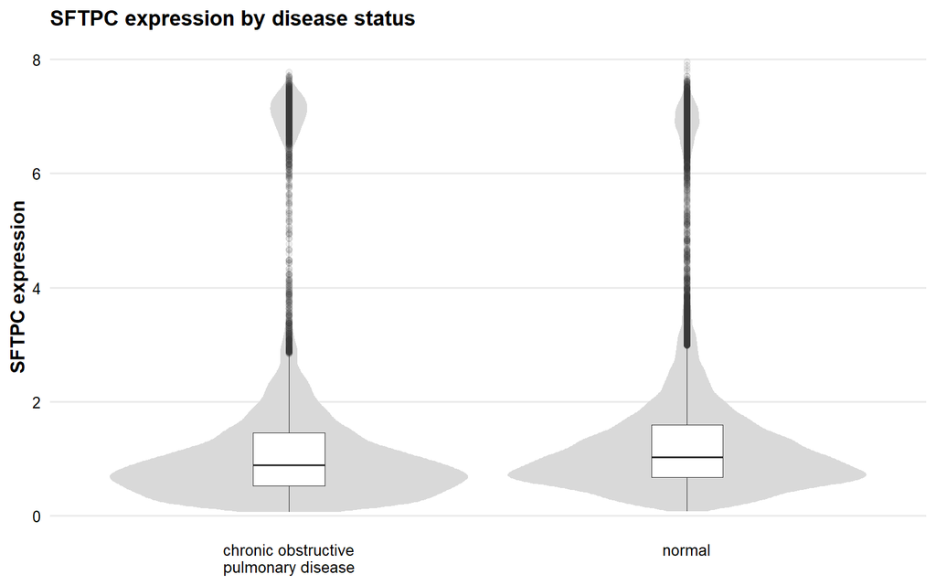

Distribution of nonzero SFTPC expression by disease group.

```r
ggplot(full_df %>% filter(SFTPC > 0), aes(x = disease, y = SFTPC)) +
  geom_violin(fill = "gray85", color = NA, scale = "width") +
  geom_boxplot(width = 0.18, outlier.alpha = 0.08, linewidth = 0.3) +
  scale_x_discrete(labels = wrap_axis) +
  labs(
    title = "SFTPC expression by disease status",
    x = NULL,
    y = "SFTPC expression"
  )
```

This plot shows that nonzero SFTPC expression is shifted downward in COPD relative to normal tissue, which matches the lower summary statistics for COPD.

The following figure compares AGER expression distributions across disease groups.

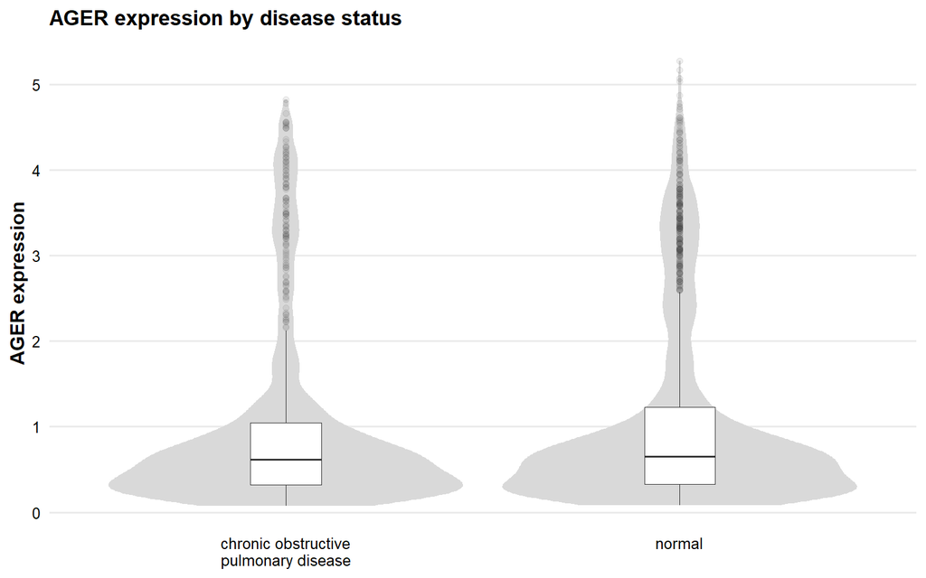

Distribution of nonzero AGER expression by disease group.

```r
ggplot(full_df %>% filter(AGER > 0), aes(x = disease, y = AGER)) +
  geom_violin(fill = "gray85", color = NA, scale = "width") +
  geom_boxplot(width = 0.18, outlier.alpha = 0.08, linewidth = 0.3) +
  scale_x_discrete(labels = wrap_axis) +
  labs(
    title = "AGER expression by disease status",
    x = NULL,
    y = "AGER expression"
  )
```

This plot suggests that nonzero AGER expression is also somewhat lower in COPD than in normal tissue, though the difference appears less pronounced than for SFTPC.